# **Modelo de riesgo de crédito**

### Julian Esteban Carvajal Ramírez 1001774262

### Wilfer Mauricio Chavarría Jaramillo 1035833003

### Alejandro Bedoya Taborda 1152226157

# **REPORTE TÉCNICO**

**INTRODUCCIÓN**

La industria de los servicios financieros, es un mercado que cada día está creciendo y evolucionando constantemente, esto lleva a que diversas empresas inviertan más dinero en estadísticos predictivos para aumentar sus ganancias y reducir los riesgos de inversión.

Este documento se centra en los préstamos de dinero y la probabilidad de que una persona pague responsablemente su deuda, para calcular esta probabilidad, normalmente las entidades bancarias tienen en cuenta el “puntaje crediticio” Gracias a esa clasificación, analizan su historial de pago, reporte a centrales de riesgo y crean un perfil sobre su capacidad económica para aprobar o no créditos. El puntaje crediticio, también llamado score, se mide de 0 a 1.000 puntos. Este depende de varios factores, por ejemplo: cumplimiento del pago de cuotas de otros créditos, nivel de endeudamiento de las personas y pagos de telefonía móvil, entre otros.

**OBJETIVO**

- Crear y validar un modelo de probabilidad de incumplimiento para la base de datos loan_data_2007_2014.csv suministrada por el profesor en el curso.
- Representar con datos estadísticos en un modelo scorecard los resultados obtenidos.
- Analizar qué posibles variables hacen que una persona presente una mayor probabilidad de no pagar el préstamo.
- Presentar todos los resultados obtenidos en una aplicación web y dar explicación de los mismos.

**BASE DE DATOS**

La base de datos utilizada es este proyecto es loan_data_2007_2014.csv (https://classroom.google.com/c/NDc0MTYzNDgwNzI3/a/NDg2NTU0MjYwMjcw/details) suministrada por el profesor.

Para el análisis de esta base de datos, se hace un trabajo de pre-procesamiento de datos, el cual consiste en: Eliminar todas las variables o campos que contengan el 80% o más de datos nulos o casillas vacías. Realizar un data cleaning para las variables que son candidatas de llevar a la simulación como lo son 'emp_length' y 'term' que requieren ser llevadas a tipo numérico y llevaremos las columnas con fechas al formato de fecha de python. Se realiza la prueba del Chi-cuadrado para las variables características categóricas y el estadístico F de ANOVA para las características numéricas. Se seleccionan las variables a incluir en el modelo Después de explorar y limpiar los datos de la base de datos, procedemos a aplicar las técnicas de WoE y VI Con base en la proporción de buenos y malos solicitantes en cada nivel de grupo, este método mide la "fuerza" de la agrupación para diferenciar el riesgo bueno y el malo e intenta encontrar una relación monótona entre las variables independientes y la variable objetivo.

Por último se calcula la probabilidad de cumplimiento de pago de cada individuo, a partir de estos datos se pueden obtener resultados y conclusiones.

**RECOMENDACIONES**

- Si se desea realizar préstamos con duración de más de 12 meses, se recomienda analizar nuevamente cada sujeto en el tiempo en que desee sacar el crédito, para tener una puntuación de ScoreCard más precisa y una probabilidad de pago total de la deuda igual de precisa.
- Se recomienda que al momento de la recolección de datos, se aseguren de no tener valores nulos, pues al depurar la base de datos esto generó mucha pérdida de información valiosa.
- Se recomienda Realizar un análisis más profundo de la probabilidad de pago de cada individuo mes a mes, pues esto cambiaría significativamente los resultados de la puntuación de ScoreCard.

# Importes

```python
!pip install funpymodeling
```

```python
import pathlib
import pandas as pd
import seaborn as sns
from funpymodeling.exploratory import corr_pair
import numpy as np
import matplotlib.pyplot as plt
from sklearn.model_selection import train_test_split, RepeatedStratifiedKFold, cross_val_score
from sklearn.linear_model import LogisticRegression
from sklearn.metrics import roc_curve, roc_auc_score, confusion_matrix, precision_recall_curve, auc
from sklearn.feature_selection import f_classif
from sklearn.pipeline import Pipeline
from sklearn.base import BaseEstimator, TransformerMixin
from scipy.stats import chi2_contingency
from sklearn.metrics import roc_auc_score
from sklearn.metrics import f1_score
from sklearn.metrics import accuracy_score
from sklearn.metrics import confusion_matrix
```

```python
from google.colab import drive
drive.mount('/content/drive')
```

```python
data_path = pathlib.Path('/content/drive/Shareddrives/Tecnicas de aprendizaje estadistico/Entrega 2')
list(data_path.glob('*.csv'))
```

```
[PosixPath('/content/drive/Shareddrives/Tecnicas de aprendizaje estadistico/Entrega 2/loan_data_2007_2014.csv'),
 PosixPath('/content/drive/Shareddrives/Tecnicas de aprendizaje estadistico/Entrega 2/modelo.csv')]
```

```python
data = pd.read_csv(data_path.joinpath('loan_data_2007_2014.csv'), index_col=0)
data
```

| id | member_id | loan_amnt | funded_amnt | funded_amnt_inv | term | int_rate | installment | grade | sub_grade | emp_title | ... | total_bal_il | il_util | open_rv_12m | open_rv_24m | max_bal_bc | all_util | total_rev_hi_lim | inq_fi | total_cu_tl | inq_last_12m |
| --- | --- | --- | --- | --- | --- | --- | --- | --- | --- | --- | --- | --- | --- | --- | --- | --- | --- | --- | --- | --- | --- |
| 1077501 | 1296599 | 5000 | 5000 | 4975.0 | 36 months | 10.65 | 162.87 | B | B2 | NaN | ... | NaN | NaN | NaN | NaN | NaN | NaN | NaN | NaN | NaN | NaN |
| 1077430 | 1314167 | 2500 | 2500 | 2500.0 | 60 months | 15.27 | 59.83 | C | C4 | Ryder | ... | NaN | NaN | NaN | NaN | NaN | NaN | NaN | NaN | NaN | NaN |
| 1077175 | 1313524 | 2400 | 2400 | 2400.0 | 36 months | 15.96 | 84.33 | C | C5 | NaN | ... | NaN | NaN | NaN | NaN | NaN | NaN | NaN | NaN | NaN | NaN |
| 1076863 | 1277178 | 10000 | 10000 | 10000.0 | 36 months | 13.49 | 339.31 | C | C1 | AIR RESOURCES BOARD | ... | NaN | NaN | NaN | NaN | NaN | NaN | NaN | NaN | NaN | NaN |
| 1075358 | 1311748 | 3000 | 3000 | 3000.0 | 60 months | 12.69 | 67.79 | B | B5 | University Medical Group | ... | NaN | NaN | NaN | NaN | NaN | NaN | NaN | NaN | NaN | NaN |
| ... | ... | ... | ... | ... | ... | ... | ... | ... | ... | ... | ... | ... | ... | ... | ... | ... | ... | ... | ... | ... | ... |
| 8598660 | 1440975 | 18400 | 18400 | 18400.0 | 60 months | 14.47 | 432.64 | C | C2 | Financial Advisor | ... | NaN | NaN | NaN | NaN | NaN | NaN | 29900.0 | NaN | NaN | NaN |
| 9684700 | 11536848 | 22000 | 22000 | 22000.0 | 60 months | 19.97 | 582.50 | D | D5 | Chief of Interpretation (Park Ranger) | ... | NaN | NaN | NaN | NaN | NaN | NaN | 39400.0 | NaN | NaN | NaN |
| 9584776 | 11436914 | 20700 | 20700 | 20700.0 | 60 months | 16.99 | 514.34 | D | D1 | patrol | ... | NaN | NaN | NaN | NaN | NaN | NaN | 13100.0 | NaN | NaN | NaN |
| 9604874 | 11457002 | 2000 | 2000 | 2000.0 | 36 months | 7.90 | 62.59 | A | A4 | Server Engineer Lead | ... | NaN | NaN | NaN | NaN | NaN | NaN | 53100.0 | NaN | NaN | NaN |
| 9199665 | 11061576 | 10000 | 10000 | 9975.0 | 36 months | 19.20 | 367.58 | D | D3 | NaN | ... | NaN | NaN | NaN | NaN | NaN | NaN | 16000.0 | NaN | NaN | NaN |

466285 rows × 73 columns

# Preprocesamiento

Se saca información de la tabla para saber cuántas columnas tiene, cuáles y cuántas no nulos tiene cada columna.

```python
data.info()
```

```
<class 'pandas.core.frame.DataFrame'>
Int64Index: 466285 entries, 1077501 to 9199665
Data columns (total 73 columns):
 #   Column                       Non-Null Count   Dtype
---  ------                       --------------   -----
 0   member_id                    466285 non-null  int64
 1   loan_amnt                    466285 non-null  int64
 2   funded_amnt                  466285 non-null  int64
 3   funded_amnt_inv              466285 non-null  float64
 4   term                         466285 non-null  object
 5   int_rate                     466285 non-null  float64
 6   installment                  466285 non-null  float64
 7   grade                        466285 non-null  object
 8   sub_grade                    466285 non-null  object
 9   emp_title                    438697 non-null  object
```

[output cut: 65 more lines]

Se eliminan las columnas con solamente nulos

```python
data =data.drop(columns=[
                         'annual_inc_joint','dti_joint','verification_status_joint','open_acc_6m','open_il_6m','open_il_12m',
                         'mths_since_rcnt_il',
                         'total_bal_il',
                         'il_util',
                         'open_rv_12m',
                         'open_rv_24m',
                         'max_bal_bc',
                         'all_util','inq_fi','total_cu_tl','inq_last_12m'])
data
```

| id | member_id | loan_amnt | funded_amnt | funded_amnt_inv | term | int_rate | installment | grade | sub_grade | emp_title | ... | last_credit_pull_d | collections_12_mths_ex_med | mths_since_last_major_derog | policy_code | application_type | acc_now_delinq | tot_coll_amt | tot_cur_bal | open_il_24m | total_rev_hi_lim |
| --- | --- | --- | --- | --- | --- | --- | --- | --- | --- | --- | --- | --- | --- | --- | --- | --- | --- | --- | --- | --- | --- |
| 1077501 | 1296599 | 5000 | 5000 | 4975.0 | 36 months | 10.65 | 162.87 | B | B2 | NaN | ... | Jan-16 | 0.0 | NaN | 1 | INDIVIDUAL | 0.0 | NaN | NaN | NaN | NaN |
| 1077430 | 1314167 | 2500 | 2500 | 2500.0 | 60 months | 15.27 | 59.83 | C | C4 | Ryder | ... | Sep-13 | 0.0 | NaN | 1 | INDIVIDUAL | 0.0 | NaN | NaN | NaN | NaN |
| 1077175 | 1313524 | 2400 | 2400 | 2400.0 | 36 months | 15.96 | 84.33 | C | C5 | NaN | ... | Jan-16 | 0.0 | NaN | 1 | INDIVIDUAL | 0.0 | NaN | NaN | NaN | NaN |
| 1076863 | 1277178 | 10000 | 10000 | 10000.0 | 36 months | 13.49 | 339.31 | C | C1 | AIR RESOURCES BOARD | ... | Jan-15 | 0.0 | NaN | 1 | INDIVIDUAL | 0.0 | NaN | NaN | NaN | NaN |
| 1075358 | 1311748 | 3000 | 3000 | 3000.0 | 60 months | 12.69 | 67.79 | B | B5 | University Medical Group | ... | Jan-16 | 0.0 | NaN | 1 | INDIVIDUAL | 0.0 | NaN | NaN | NaN | NaN |
| ... | ... | ... | ... | ... | ... | ... | ... | ... | ... | ... | ... | ... | ... | ... | ... | ... | ... | ... | ... | ... | ... |
| 8598660 | 1440975 | 18400 | 18400 | 18400.0 | 60 months | 14.47 | 432.64 | C | C2 | Financial Advisor | ... | Jan-16 | 0.0 | NaN | 1 | INDIVIDUAL | 0.0 | 0.0 | 294998.0 | NaN | 29900.0 |
| 9684700 | 11536848 | 22000 | 22000 | 22000.0 | 60 months | 19.97 | 582.50 | D | D5 | Chief of Interpretation (Park Ranger) | ... | Jan-16 | 0.0 | NaN | 1 | INDIVIDUAL | 0.0 | 0.0 | 221830.0 | NaN | 39400.0 |
| 9584776 | 11436914 | 20700 | 20700 | 20700.0 | 60 months | 16.99 | 514.34 | D | D1 | patrol | ... | Dec-15 | 0.0 | NaN | 1 | INDIVIDUAL | 0.0 | 0.0 | 73598.0 | NaN | 13100.0 |
| 9604874 | 11457002 | 2000 | 2000 | 2000.0 | 36 months | 7.90 | 62.59 | A | A4 | Server Engineer Lead | ... | Apr-15 | 0.0 | NaN | 1 | INDIVIDUAL | 0.0 | 0.0 | 591610.0 | NaN | 53100.0 |
| 9199665 | 11061576 | 10000 | 10000 | 9975.0 | 36 months | 19.20 | 367.58 | D | D3 | NaN | ... | Jan-16 | 0.0 | NaN | 1 | INDIVIDUAL | 0.0 | 0.0 | 57477.0 | NaN | 16000.0 |

466285 rows × 57 columns

Se borran las columnas con más de 80% de valores como nulos

```python
data.dropna(thresh = data.shape[0]*0.2, how = 'all', axis = 1, inplace = True)
```

Así como las columnas que no están relacionadas con el riesgo de crédito como el id del mienbro por ejemplo

```python
data.drop(columns = ['member_id', 'sub_grade', 'emp_title', 'url', 'desc', 'title',
                          'zip_code', 'next_pymnt_d', 'recoveries', 'collection_recovery_fee',
                          'total_rec_prncp', 'total_rec_late_fee'], inplace = True)
```

Se hace un resumen de los datos

```python
data.info()
```

```
<class 'pandas.core.frame.DataFrame'>
Int64Index: 466285 entries, 1077501 to 9199665
Data columns (total 43 columns):
 #   Column                       Non-Null Count   Dtype
---  ------                       --------------   -----
 0   loan_amnt                    466285 non-null  int64
 1   funded_amnt                  466285 non-null  int64
 2   funded_amnt_inv              466285 non-null  float64
 3   term                         466285 non-null  object
 4   int_rate                     466285 non-null  float64
 5   installment                  466285 non-null  float64
 6   grade                        466285 non-null  object
 7   emp_length                   445277 non-null  object
 8   home_ownership               466285 non-null  object
 9   annual_inc                   466281 non-null  float64
```

[output cut: 35 more lines]

```python
data['policy_code'].value_counts(normalize = True)
```

```
1    1.0
Name: policy_code, dtype: float64
```

```python
data.drop(columns = ['policy_code'], inplace = True)
```

Es necesario realizar un data cleaning para las variables que son candidatas de llevar a la simulación como lo son 'emp_length' y 'term' que requieren ser llevadas a tipo numérico y llevaremos las columnas con fechas al formato de fecha de python.

```python
data['emp_length'].value_counts(normalize = True)
```

```
10+ years    0.336979
2 years      0.092915
3 years      0.082187
< 1 year     0.081444
5 years      0.069112
1 year       0.066525
4 years      0.062934
7 years      0.058795
6 years      0.058642
8 years      0.050295
9 years      0.040173
Name: emp_length, dtype: float64
```

```python
data['emp_length'] = data['emp_length'].str.replace('\+ years', '')
data['emp_length'] = data['emp_length'].str.replace('< 1 year', str(0))
data['emp_length'] = data['emp_length'].str.replace(' years', '')
data['emp_length'] = data['emp_length'].str.replace(' year', '')
data['emp_length'] = pd.to_numeric(data['emp_length'])
data['emp_length'].fillna(value = 0, inplace = True)
data['emp_length'].value_counts(normalize = True)
```

```
10.0    0.321797
0.0     0.122828
2.0     0.088729
3.0     0.078484
5.0     0.065998
1.0     0.063528
4.0     0.060098
7.0     0.056146
6.0     0.056000
8.0     0.048029
9.0     0.038363
Name: emp_length, dtype: float64
```

```python
data['term'].value_counts(normalize = True)
```

```
 36 months    0.724778
 60 months    0.275222
Name: term, dtype: float64
```

```python
data['term'] = pd.to_numeric(data['term'].str.replace(' months', ''))
data['term'].value_counts(normalize = True)
```

```
36    0.724778
60    0.275222
Name: term, dtype: float64
```

```python
# Función para pasar las columnas con fechas a datatime de python
def date_columns(df, column):
    # store current month
    today_date = pd.to_datetime('2020-08-01')
    # convert to datetime format
    df[column] = pd.to_datetime(df[column], format = "%b-%y")
    # calculate the difference in months and add to a new column
    df['mths_since_' + column] = round(pd.to_numeric((today_date - df[column]) /
							np.timedelta64(1, 'M')))
    # make any resulting -ve values to be equal to the max date
    df['mths_since_' + column] = df['mths_since_' + column].apply(
		lambda x: df['mths_since_' + column].max() if x < 0 else x)
    # drop the original date column
    df.drop(columns = [column], inplace = True)
```

```python
date_columns(data, 'earliest_cr_line')
date_columns(data, 'issue_d')
date_columns(data, 'last_pymnt_d')
date_columns(data, 'last_credit_pull_d')
```

# Selección de variables

```python
data['loan_status'].value_counts(normalize = True)
```

```
Current                                                0.480878
Fully Paid                                             0.396193
Charged Off                                            0.091092
Late (31-120 days)                                     0.014798
In Grace Period                                        0.006747
Does not meet the credit policy. Status:Fully Paid     0.004263
Late (16-30 days)                                      0.002612
Default                                                0.001784
Does not meet the credit policy. Status:Charged Off    0.001632
Name: loan_status, dtype: float64
```

Hay 9 posibles valores para loan_status.

- Fully Paid
- Charged Off
- Current
- Default
- Late (31-120 days)
- In Grace Period
- Late (16-30 days)
- Does not meet the credit policy.
- Status:Fully Paid Does not meet the credit policy. Status:Charged Off

```python
# Creamos una nueva columna basada en la variable objetivo para usarla en el entrenamiento

data['good_bad'] = np.where(data.loc[:, 'loan_status'].isin(['Charged Off', 'Default',
                                                                       'Late (31-120 days)',
                                                                       'Does not meet the credit policy. Status:Charged Off']),0, 1)

# Es necesario borrar la variable objetivo original para que no interfiera en el modelo 'loan_status'
data.drop(columns = ['loan_status'], inplace = True)
```

Las 9 variables de loan status se convirtieron en las siguientes variabales categoricas númericas.

En el grupo de los 'buena paga' o 1 se tienen:

- Fully Paid
- Current
- In Grace Period
- Late (16-30 days)
- Does not meet the credit policy.

En el grupo de los 'mala paga' o 0 se tienen:

- Charged Off
- Default
- Late (31-120 days)
- Status:Fully Paid Does not meet the credit policy. Status:Charged Off

```python
# Se hace el split 80-20 para el dataset de entrenamiento y de testeo

X = data.drop('good_bad', axis = 1)
y = data['good_bad']
X_train, X_test, y_train, y_test = train_test_split(X, y, test_size = 0.2,
                                                    random_state = 42, stratify = y)

X_train, X_test = X_train.copy(), X_test.copy()
```

Para continuar con la selección de variables realizaremos una prueba de Chi-cuadrado para las variables características categóricas y el estadístico F de ANOVA para las características numéricas

```python
# Primero dividimos el subset de entrenamiento en subsets categoricos y numéricos

X_train_cat = X_train.select_dtypes(include = 'object').copy()
X_train_num = X_train.select_dtypes(include = 'number').copy()

# Definimos un diccionario vacío para almacenar los resultados del Chi-cuadrado
chi2_check = {}
```

```python
# Se calcula el Chi-cuadrado para cada columna haciendo uso de la variable objetivo

for column in X_train_cat:
    chi, p, dof, ex = chi2_contingency(pd.crosstab(y_train, X_train_cat[column]))
    chi2_check.setdefault('Feature',[]).append(column)
    chi2_check.setdefault('p-value',[]).append(round(p, 10))
```

```python
# Convertimos el diccionario a DataFrame

chi2_result = pd.DataFrame(data = chi2_check)
chi2_result.sort_values(by = ['p-value'], ascending = True, ignore_index = True, inplace = True)
```

```python
# La función a usar para calcular los F Statistis no acepta N/A así que los llenaremos

X_train_num.fillna(X_train_num.mean(), inplace = True)
```

```python
# Calculando el  F Statistic y sus correspondientes P values

F_statistic, p_values = f_classif(X_train_num, y_train)

# convert to a DF
ANOVA_F_table = pd.DataFrame(data = {'Numerical_Feature': X_train_num.columns.values,
					'F-Score': F_statistic, 'p values': p_values.round(decimals=10)})
ANOVA_F_table.sort_values(by = ['F-Score'], ascending = False, ignore_index = True, inplace = True)
```

```python
# save the top 20 numerical features in a list
top_num_features = ANOVA_F_table.iloc[:20,0].to_list()
top_num_features
```

```
['mths_since_last_pymnt_d',
 'total_pymnt_inv',
 'total_pymnt',
 'int_rate',
 'last_pymnt_amnt',
 'out_prncp',
 'out_prncp_inv',
 'mths_since_last_credit_pull_d',
 'mths_since_issue_d',
 'inq_last_6mths',
 'term',
 'revol_util',
 'dti',
 'annual_inc',
 'tot_cur_bal',
 'mths_since_earliest_cr_line',
 'total_rev_hi_lim',
 'total_rec_int',
 'total_acc',
 'emp_length']
```

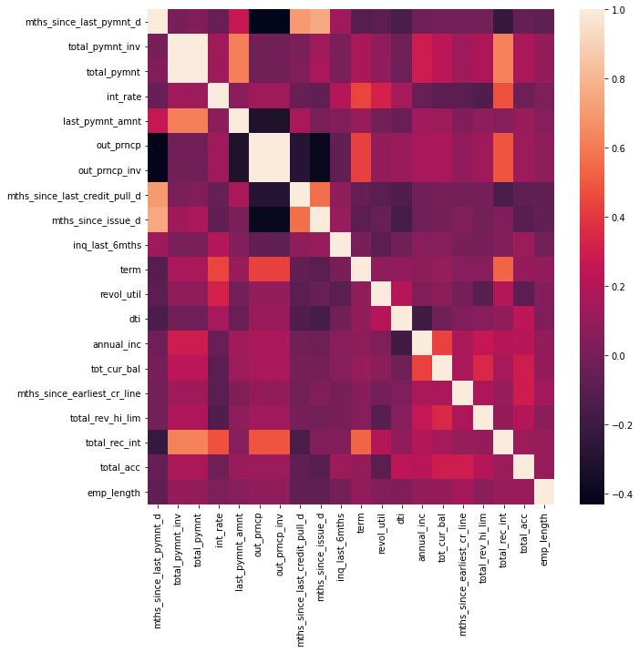

```python
# Matriz de correlaciones para estas variables
corrmat = X_train_num[top_num_features].corr()
plt.figure(figsize=(10,10))
sns.heatmap(corrmat)
```

```python
# Guardamos el nombre de las demás columnas para luego borrarlas

drop_columns_list = ANOVA_F_table.iloc[20:, 0].to_list()
drop_columns_list.extend(chi2_result.iloc[4:, 0].to_list())
drop_columns_list.extend(['out_prncp_inv', 'total_pymnt_inv'])
```

```python
# Se borran
X_train.drop(columns = drop_columns_list, inplace = True)
```

```python
# function to create dummy variables
def dummy_creation(df, columns_list):
    df_dummies = []
    for col in columns_list:
        df_dummies.append(pd.get_dummies(df[col], prefix = col, prefix_sep = ':'))
    df_dummies = pd.concat(df_dummies, axis = 1)
    df = pd.concat([df, df_dummies], axis = 1)
    return df

# apply to our final four categorical variables
X_train = dummy_creation(X_train, ['grade', 'home_ownership', 'verification_status', 'purpose'])

X_test.drop(columns = drop_columns_list, inplace = True)
X_test = dummy_creation(X_test, ['grade', 'home_ownership', 'verification_status', 'purpose'])
# reindex the dummied test set variables to make sure all the feature columns in the training set are also available in the test set
X_test = X_test.reindex(labels=X_train.columns, axis=1, fill_value=0)
```

# **Modelo de Incumplimiento**

```python
#
# function to calculate WoE and IV of categorical features
# The function takes 3 arguments: a dataframe (X_train_prepr), a string (column name), and a dataframe (y_train_prepr).
def woe_discrete(df, cat_variabe_name, y_df):
    df = pd.concat([df[cat_variabe_name], y_df], axis = 1)
    df = pd.concat([df.groupby(df.columns.values[0], as_index = False)[df.columns.values[1]].count(),
                    df.groupby(df.columns.values[0], as_index = False)[df.columns.values[1]].mean()], axis = 1)
    df = df.iloc[:, [0, 1, 3]]
    df.columns = [df.columns.values[0], 'n_obs', 'prop_good']
    df['prop_n_obs'] = df['n_obs'] / df['n_obs'].sum()
    df['n_good'] = df['prop_good'] * df['n_obs']
    df['n_bad'] = (1 - df['prop_good']) * df['n_obs']
    df['prop_n_good'] = df['n_good'] / df['n_good'].sum()
    df['prop_n_bad'] = df['n_bad'] / df['n_bad'].sum()
    df['WoE'] = np.log(df['prop_n_good'] / df['prop_n_bad'])
    df = df.sort_values(['WoE'])
    df = df.reset_index(drop = True)
    df['diff_prop_good'] = df['prop_good'].diff().abs()
    df['diff_WoE'] = df['WoE'].diff().abs()
    df['IV'] = (df['prop_n_good'] - df['prop_n_bad']) * df['WoE']
    df['IV'] = df['IV'].sum()
    return df

'''
function to calculate WoE & IV of continuous variables
This is same as the function we defined earlier for discrete variables
The only difference are the 2 commented lines of code in the function that results in the df
being sorted by continuous variable values
'''
def woe_ordered_continuous(df, continuous_variabe_name, y_df):
    df = pd.concat([df[continuous_variabe_name], y_df], axis = 1)
    df = pd.concat([df.groupby(df.columns.values[0], as_index = False)[df.columns.values[1]].count(),
                    df.groupby(df.columns.values[0], as_index = False)[df.columns.values[1]].mean()], axis = 1)
    df = df.iloc[:, [0, 1, 3]]
    df.columns = [df.columns.values[0], 'n_obs', 'prop_good']
    df['prop_n_obs'] = df['n_obs'] / df['n_obs'].sum()
    df['n_good'] = df['prop_good'] * df['n_obs']
    df['n_bad'] = (1 - df['prop_good']) * df['n_obs']
    df['prop_n_good'] = df['n_good'] / df['n_good'].sum()
    df['prop_n_bad'] = df['n_bad'] / df['n_bad'].sum()
    df['WoE'] = np.log(df['prop_n_good'] / df['prop_n_bad'])
    #df = df.sort_values(['WoE'])
    #df = df.reset_index(drop = True)
    df['diff_prop_good'] = df['prop_good'].diff().abs()
    df['diff_WoE'] = df['WoE'].diff().abs()
    df['IV'] = (df['prop_n_good'] - df['prop_n_bad']) * df['WoE']
    df['IV'] = df['IV'].sum()
    return df

# We set the default style of the graphs to the seaborn style.
sns.set()
# function to plot WoE value
def plot_by_woe(df_WoE, rotation_of_x_axis_labels = 0):
    x = np.array(df_WoE.iloc[:, 0].apply(str))
    y = df_WoE['WoE']
    plt.figure(figsize=(18, 6))
    plt.plot(x, y, marker = 'o', linestyle = '--', color = 'k')
    plt.xlabel(df_WoE.columns[0])
    plt.ylabel('Weight of Evidence')
    plt.title(str('Weight of Evidence by ' + df_WoE.columns[0]))
    plt.xticks(rotation = rotation_of_x_axis_labels)

# create a list of all the reference categories, i.e. one category from each of the global features
ref_categories = ['mths_since_last_credit_pull_d:>75', 'mths_since_issue_d:>122', 'mths_since_earliest_cr_line:>434', 'total_rev_hi_lim:>79,780',
                  'total_rec_int:>7,260', 'total_pymnt:>25,000', 'out_prncp:>15,437', 'revol_util:>1.0', 'inq_last_6mths:>4', 'dti:>35.191',
                  'annual_inc:>150K', 'int_rate:>20.281', 'term:60', 'purpose:major_purch__car__home_impr', 'verification_status:Not Verified',
                  'home_ownership:MORTGAGE', 'grade:G']

# custom transformer class to create new categorical dummy features
class WoE_Binning(BaseEstimator, TransformerMixin):
    def __init__(self, X): # no *args or *kargs
        self.X = X
    def fit(self, X, y = None):
        return self #nothing else to do
    def transform(self, X):
        X_new = X.loc[:, 'grade:A': 'grade:G']
        X_new['home_ownership:OWN'] = X.loc[:,'home_ownership:OWN']
        X_new['home_ownership:MORTGAGE'] = X.loc[:,'home_ownership:MORTGAGE']
        X_new['home_ownership:OTHER_NONE_RENT'] = sum([X['home_ownership:OTHER'], X['home_ownership:NONE'], X['home_ownership:RENT']])
        X_new = pd.concat([X_new, X.loc[:, 'verification_status:Not Verified':'verification_status:Verified']], axis = 1)
        X_new['purpose:debt_consolidation'] = X.loc[:,'purpose:debt_consolidation']
        X_new['purpose:credit_card'] = X.loc[:,'purpose:credit_card']
        X_new['purpose:major_purch__car__home_impr'] = sum([X['purpose:major_purchase'], X['purpose:car'], X['purpose:home_improvement']])
        X_new['purpose:educ__ren_en__sm_b__mov'] = sum([X['purpose:educational'], X['purpose:renewable_energy'], X['purpose:small_business'],
                                                        X['purpose:moving']])
        X_new['purpose:vacation__house__wedding__med__oth'] = sum([X['purpose:vacation'], X['purpose:house'], X['purpose:wedding'],
                                                                   X['purpose:medical'], X['purpose:other']])
        X_new['term:36'] = np.where((X['term'] == 36), 1, 0)
        X_new['term:60'] = np.where((X['term'] == 60), 1, 0)
        X_new['int_rate:<7.071'] = np.where((X['int_rate'] <= 7.071), 1, 0)
        X_new['int_rate:7.071-10.374'] = np.where((X['int_rate'] > 7.071) & (X['int_rate'] <= 10.374), 1, 0)
        X_new['int_rate:10.374-13.676'] = np.where((X['int_rate'] > 10.374) & (X['int_rate'] <= 13.676), 1, 0)
        X_new['int_rate:13.676-15.74'] = np.where((X['int_rate'] > 13.676) & (X['int_rate'] <= 15.74), 1, 0)
        X_new['int_rate:15.74-20.281'] = np.where((X['int_rate'] > 15.74) & (X['int_rate'] <= 20.281), 1, 0)
        X_new['int_rate:>20.281'] = np.where((X['int_rate'] > 20.281), 1, 0)
        X_new['annual_inc:missing'] = np.where(X['annual_inc'].isnull(), 1, 0)
        X_new['annual_inc:<28,555'] = np.where((X['annual_inc'] <= 28555), 1, 0)
        X_new['annual_inc:28,555-37,440'] = np.where((X['annual_inc'] > 28555) & (X['annual_inc'] <= 37440), 1, 0)
        X_new['annual_inc:37,440-61,137'] = np.where((X['annual_inc'] > 37440) & (X['annual_inc'] <= 61137), 1, 0)
        X_new['annual_inc:61,137-81,872'] = np.where((X['annual_inc'] > 61137) & (X['annual_inc'] <= 81872), 1, 0)
        X_new['annual_inc:81,872-102,606'] = np.where((X['annual_inc'] > 81872) & (X['annual_inc'] <= 102606), 1, 0)
        X_new['annual_inc:102,606-120,379'] = np.where((X['annual_inc'] > 102606) & (X['annual_inc'] <= 120379), 1, 0)
        X_new['annual_inc:120,379-150,000'] = np.where((X['annual_inc'] > 120379) & (X['annual_inc'] <= 150000), 1, 0)
        X_new['annual_inc:>150K'] = np.where((X['annual_inc'] > 150000), 1, 0)
        X_new['dti:<=1.6'] = np.where((X['dti'] <= 1.6), 1, 0)
        X_new['dti:1.6-5.599'] = np.where((X['dti'] > 1.6) & (X['dti'] <= 5.599), 1, 0)
        X_new['dti:5.599-10.397'] = np.where((X['dti'] > 5.599) & (X['dti'] <= 10.397), 1, 0)
        X_new['dti:10.397-15.196'] = np.where((X['dti'] > 10.397) & (X['dti'] <= 15.196), 1, 0)
        X_new['dti:15.196-19.195'] = np.where((X['dti'] > 15.196) & (X['dti'] <= 19.195), 1, 0)
        X_new['dti:19.195-24.794'] = np.where((X['dti'] > 19.195) & (X['dti'] <= 24.794), 1, 0)
        X_new['dti:24.794-35.191'] = np.where((X['dti'] > 24.794) & (X['dti'] <= 35.191), 1, 0)
        X_new['dti:>35.191'] = np.where((X['dti'] > 35.191), 1, 0)
        X_new['inq_last_6mths:missing'] = np.where(X['inq_last_6mths'].isnull(), 1, 0)
        X_new['inq_last_6mths:0'] = np.where((X['inq_last_6mths'] == 0), 1, 0)
        X_new['inq_last_6mths:1-2'] = np.where((X['inq_last_6mths'] >= 1) & (X['inq_last_6mths'] <= 2), 1, 0)
        X_new['inq_last_6mths:3-4'] = np.where((X['inq_last_6mths'] >= 3) & (X['inq_last_6mths'] <= 4), 1, 0)
        X_new['inq_last_6mths:>4'] = np.where((X['inq_last_6mths'] > 4), 1, 0)
        X_new['revol_util:missing'] = np.where(X['revol_util'].isnull(), 1, 0)
        X_new['revol_util:<0.1'] = np.where((X['revol_util'] <= 0.1), 1, 0)
        X_new['revol_util:0.1-0.2'] = np.where((X['revol_util'] > 0.1) & (X['revol_util'] <= 0.2), 1, 0)
        X_new['revol_util:0.2-0.3'] = np.where((X['revol_util'] > 0.2) & (X['revol_util'] <= 0.3), 1, 0)
        X_new['revol_util:0.3-0.4'] = np.where((X['revol_util'] > 0.3) & (X['revol_util'] <= 0.4), 1, 0)
        X_new['revol_util:0.4-0.5'] = np.where((X['revol_util'] > 0.4) & (X['revol_util'] <= 0.5), 1, 0)
        X_new['revol_util:0.5-0.6'] = np.where((X['revol_util'] > 0.5) & (X['revol_util'] <= 0.6), 1, 0)
        X_new['revol_util:0.6-0.7'] = np.where((X['revol_util'] > 0.6) & (X['revol_util'] <= 0.7), 1, 0)
        X_new['revol_util:0.7-0.8'] = np.where((X['revol_util'] > 0.7) & (X['revol_util'] <= 0.8), 1, 0)
        X_new['revol_util:0.8-0.9'] = np.where((X['revol_util'] > 0.8) & (X['revol_util'] <= 0.9), 1, 0)
        X_new['revol_util:0.9-1.0'] = np.where((X['revol_util'] > 0.9) & (X['revol_util'] <= 1.0), 1, 0)
        X_new['revol_util:>1.0'] = np.where((X['revol_util'] > 1.0), 1, 0)
        X_new['out_prncp:<1,286'] = np.where((X['out_prncp'] <= 1286), 1, 0)
        X_new['out_prncp:1,286-6,432'] = np.where((X['out_prncp'] > 1286) & (X['out_prncp'] <= 6432), 1, 0)
        X_new['out_prncp:6,432-9,005'] = np.where((X['out_prncp'] > 6432) & (X['out_prncp'] <= 9005), 1, 0)
        X_new['out_prncp:9,005-10,291'] = np.where((X['out_prncp'] > 9005) & (X['out_prncp'] <= 10291), 1, 0)
        X_new['out_prncp:10,291-15,437'] = np.where((X['out_prncp'] > 10291) & (X['out_prncp'] <= 15437), 1, 0)
        X_new['out_prncp:>15,437'] = np.where((X['out_prncp'] > 15437), 1, 0)
        X_new['total_pymnt:<10,000'] = np.where((X['total_pymnt'] <= 10000), 1, 0)
        X_new['total_pymnt:10,000-15,000'] = np.where((X['total_pymnt'] > 10000) & (X['total_pymnt'] <= 15000), 1, 0)
        X_new['total_pymnt:15,000-20,000'] = np.where((X['total_pymnt'] > 15000) & (X['total_pymnt'] <= 20000), 1, 0)
        X_new['total_pymnt:20,000-25,000'] = np.where((X['total_pymnt'] > 20000) & (X['total_pymnt'] <= 25000), 1, 0)
        X_new['total_pymnt:>25,000'] = np.where((X['total_pymnt'] > 25000), 1, 0)
        X_new['total_rec_int:<1,089'] = np.where((X['total_rec_int'] <= 1089), 1, 0)
        X_new['total_rec_int:1,089-2,541'] = np.where((X['total_rec_int'] > 1089) & (X['total_rec_int'] <= 2541), 1, 0)
        X_new['total_rec_int:2,541-4,719'] = np.where((X['total_rec_int'] > 2541) & (X['total_rec_int'] <= 4719), 1, 0)
        X_new['total_rec_int:4,719-7,260'] = np.where((X['total_rec_int'] > 4719) & (X['total_rec_int'] <= 7260), 1, 0)
        X_new['total_rec_int:>7,260'] = np.where((X['total_rec_int'] > 7260), 1, 0)
        X_new['total_rev_hi_lim:missing'] = np.where(X['total_rev_hi_lim'].isnull(), 1, 0)
        X_new['total_rev_hi_lim:<6,381'] = np.where((X['total_rev_hi_lim'] <= 6381), 1, 0)
        X_new['total_rev_hi_lim:6,381-19,144'] = np.where((X['total_rev_hi_lim'] > 6381) & (X['total_rev_hi_lim'] <= 19144), 1, 0)
        X_new['total_rev_hi_lim:19,144-25,525'] = np.where((X['total_rev_hi_lim'] > 19144) & (X['total_rev_hi_lim'] <= 25525), 1, 0)
        X_new['total_rev_hi_lim:25,525-35,097'] = np.where((X['total_rev_hi_lim'] > 25525) & (X['total_rev_hi_lim'] <= 35097), 1, 0)
        X_new['total_rev_hi_lim:35,097-54,241'] = np.where((X['total_rev_hi_lim'] > 35097) & (X['total_rev_hi_lim'] <= 54241), 1, 0)
        X_new['total_rev_hi_lim:54,241-79,780'] = np.where((X['total_rev_hi_lim'] > 54241) & (X['total_rev_hi_lim'] <= 79780), 1, 0)
        X_new['total_rev_hi_lim:>79,780'] = np.where((X['total_rev_hi_lim'] > 79780), 1, 0)
        X_new['mths_since_earliest_cr_line:missing'] = np.where(X['mths_since_earliest_cr_line'].isnull(), 1, 0)
        X_new['mths_since_earliest_cr_line:<125'] = np.where((X['mths_since_earliest_cr_line'] <= 125), 1, 0)
        X_new['mths_since_earliest_cr_line:125-167'] = np.where((X['mths_since_earliest_cr_line'] > 125) & (X['mths_since_earliest_cr_line'] <= 167), 1, 0)
```

```python
        X_new['mths_since_earliest_cr_line:167-249'] = np.where((X['mths_since_earliest_cr_line'] > 167) & (X['mths_since_earliest_cr_line'] <= 249), 1, 0)
        X_new['mths_since_earliest_cr_line:249-331'] = np.where((X['mths_since_earliest_cr_line'] > 249) & (X['mths_since_earliest_cr_line'] <= 331), 1, 0)
        X_new['mths_since_earliest_cr_line:331-434'] = np.where((X['mths_since_earliest_cr_line'] > 331) & (X['mths_since_earliest_cr_line'] <= 434), 1, 0)
        X_new['mths_since_earliest_cr_line:>434'] = np.where((X['mths_since_earliest_cr_line'] > 434), 1, 0)
        X_new['mths_since_issue_d:<79'] = np.where((X['mths_since_issue_d'] <= 79), 1, 0)
        X_new['mths_since_issue_d:79-89'] = np.where((X['mths_since_issue_d'] > 79) & (X['mths_since_issue_d'] <= 89), 1, 0)
        X_new['mths_since_issue_d:89-100'] = np.where((X['mths_since_issue_d'] > 89) & (X['mths_since_issue_d'] <= 100), 1, 0)
        X_new['mths_since_issue_d:100-122'] = np.where((X['mths_since_issue_d'] > 100) & (X['mths_since_issue_d'] <= 122), 1, 0)
        X_new['mths_since_issue_d:>122'] = np.where((X['mths_since_issue_d'] > 122), 1, 0)
        X_new['mths_since_last_credit_pull_d:missing'] = np.where(X['mths_since_last_credit_pull_d'].isnull(), 1, 0)
        X_new['mths_since_last_credit_pull_d:<56'] = np.where((X['mths_since_last_credit_pull_d'] <= 56), 1, 0)
        X_new['mths_since_last_credit_pull_d:56-61'] = np.where((X['mths_since_last_credit_pull_d'] > 56) & (X['mths_since_last_credit_pull_d'] <= 61), 1, 0)
        X_new['mths_since_last_credit_pull_d:61-75'] = np.where((X['mths_since_last_credit_pull_d'] > 61) & (X['mths_since_last_credit_pull_d'] <= 75), 1, 0)
        X_new['mths_since_last_credit_pull_d:>75'] = np.where((X['mths_since_last_credit_pull_d'] > 75), 1, 0)
        X_new.drop(columns = ref_categories, inplace = True)
        return X_new
```

```python
# define modeling pipeline
reg = LogisticRegression(max_iter=1000, class_weight = 'balanced')
woe_transform = WoE_Binning(X)
pipeline = Pipeline(steps=[('woe', woe_transform), ('model', reg)])

# define cross-validation criteria
cv = RepeatedStratifiedKFold(n_splits=5, n_repeats=3, random_state=1)

# fit and evaluate the logistic regression pipeline with cross-validation as defined in cv
scores = cross_val_score(pipeline, X_train, y_train, scoring = 'roc_auc', cv = cv)
AUROC = np.mean(scores)
GINI = AUROC * 2 - 1

# print the mean AUROC score and Gini
print('Mean AUROC: %.4f' % (AUROC))
print('Gini: %.4f' % (GINI))

# fit the pipeline on the whole training set
pipeline.fit(X_train, y_train)

# create a summary table
# first create a transformed training set through our WoE_Binning custom class
X_train_woe_transformed = woe_transform.fit_transform(X_train)
# Store the column names in X_train as a list
feature_name = X_train_woe_transformed.columns.values
# Create a summary table of our logistic regression model
summary_table = pd.DataFrame(columns = ['Feature name'], data = feature_name)
# Create a new column in the dataframe, called 'Coefficients'
summary_table['Coefficients'] = np.transpose(pipeline['model'].coef_)
# Increase the index of every row of the dataframe with 1 to store our model intercept in 1st row
summary_table.index = summary_table.index + 1
# Assign our model intercept to this new row
summary_table.loc[0] = ['Intercept', pipeline['model'].intercept_[0]]
# Sort the dataframe by index
summary_table.sort_index(inplace = True)
```

```
Mean AUROC: 0.8658
Gini: 0.7316
```

## Probabilidad de cumplimiento (¿12 meses?)

```python
y_hat_test = pipeline.predict(X_test)
# get the predicted probabilities
y_hat_test_proba = pipeline.predict_proba(X_test)
# select the probabilities of only the positive class (class 1 - default)
y_hat_test_proba = y_hat_test_proba[:][: , 1]

pd.DataFrame(y_hat_test_proba)
```

|  | 0 |
| --- | --- |
| 0 | 0.321290 |
| 1 | 0.902248 |
| 2 | 0.598331 |
| 3 | 0.752115 |
| 4 | 0.088167 |
| ... | ... |
| 93252 | 0.701759 |
| 93253 | 0.853159 |
| 93254 | 0.339972 |
| 93255 | 0.794043 |
| 93256 | 0.875469 |

93257 rows × 1 columns

## Accuracy

```python
accuracy_score(y_test,y_hat_test)
```

```
0.7920370588802985
```

El modelo es acertado aproximadamente 80% preciso, puesto que el accuracy nos dice que lo predecido coincide en un 0.79 con el resultado verdadero

## F1 score

```python
f1_score(y_test, y_hat_test, average='weighted')
```

```
0.8262447108313442
```

Es la media armonica del accuracy (precisión) y el recall (que mide que tan bueno es el modelo prediciendo clases postivias), entre más cercano a 1, significa que el modelo tiene alto accuracy y recall.

## Matriz de confusión

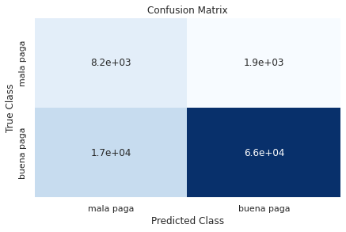

```python
import matplotlib.pyplot as plt
import seaborn as sns
from sklearn.metrics import confusion_matrix
matrix = confusion_matrix(y_test, y_hat_test)
dataframe = pd.DataFrame(matrix, index=["mala paga","buena paga"], columns=["mala paga","buena paga"])

# crear mapa de calor dibujar mapa de calor
sns.heatmap(dataframe, annot=True, cbar=None, cmap="Blues")
plt.title("Confusion Matrix"), plt.tight_layout()
plt.ylabel("True Class"), plt.xlabel("Predicted Class")
plt.show()
```

La matriz de confusión se lee diagonalmente, por lo que 8200 se predijeron correctamente como 'mala paga' y 66000 se predijeron correctamente como 'buena paga'

# Modelo Scorecard

```python
# create a new dataframe with one column with values from the 'reference_categories' list
df_ref_categories = pd.DataFrame(ref_categories, columns = ['Feature name'])
# We create a second column, called 'Coefficients', which contains only 0 values.
df_ref_categories['Coefficients'] = 0

# Concatenates two dataframes
df_scorecard = pd.concat([summary_table, df_ref_categories])
# reset the index
df_scorecard.reset_index(inplace = True)

# create a new column, called 'Original feature name', which contains the value of the 'Feature name' column
df_scorecard['Original feature name'] = df_scorecard['Feature name'].str.split(':').str[0]

# Define the min and max threshholds for our scorecard
min_score = 150
max_score = 950

# calculate the sum of the minimum coefficients of each category within the original feature name
min_sum_coef = df_scorecard.groupby('Original feature name')['Coefficients'].min().sum()
# calculate the sum of the maximum coefficients of each category within the original feature name
max_sum_coef = df_scorecard.groupby('Original feature name')['Coefficients'].max().sum()
# create a new column that has the imputed calculated Score based scaled from the coefficients
df_scorecard['Score - Calculation'] = df_scorecard['Coefficients'] * (max_score - min_score) / (
	max_sum_coef - min_sum_coef)
# update the calculated score of the Intercept
df_scorecard.loc[0, 'Score - Calculation'] = (
	(df_scorecard.loc[0,'Coefficients'] - min_sum_coef) /
	(max_sum_coef - min_sum_coef
	)) * (max_score - min_score) + min_score
# round the values of the 'Score - Calculation' column and store them in a new column
df_scorecard['Score - Preliminary'] = df_scorecard['Score - Calculation'].round()

# check the min and max possible scores of our scorecard
min_sum_score_prel = df_scorecard.groupby('Original feature name')['Score - Preliminary'].min().sum()
max_sum_score_prel = df_scorecard.groupby('Original feature name')['Score - Preliminary'].max().sum()
print(min_sum_score_prel)
print(max_sum_score_prel)

# so both our min and max scores are out by +1. we need to manually adjust this
# Which one? We'll evaluate based on the rounding differences of the minimum category within each Original Feature Name.
pd.options.display.max_rows = 102
df_scorecard['Difference'] = df_scorecard['Score - Preliminary'] - df_scorecard['Score - Calculation']

# look like we can get by deducting 1 from the Intercept
df_scorecard['Score - Final'] = df_scorecard['Score - Preliminary']
df_scorecard.loc[0, 'Score - Final'] = 585

# Recheck min and max possible scores
print(df_scorecard.groupby('Original feature name')['Score - Final'].min().sum())
print(df_scorecard.groupby('Original feature name')['Score - Final'].max().sum())

# calculate credit scores for test set
# first create a transformed test set through our WoE_Binning custom class
X_test_woe_transformed = woe_transform.fit_transform(X_test)
# insert an Intercept column in its beginning to align with the # of rows in scorecard
X_test_woe_transformed.insert(0, 'Intercept', 1)

# get the list of our final scorecard scores
scorecard_scores = df_scorecard['Score - Final']
# check the shapes of test set and scorecard before doing matrix dot multiplication
print(X_test_woe_transformed.shape)
print(scorecard_scores.shape)

# we can see that the test set has 17 less columns than the rows in scorecard due to the reference categories
# since the reference categories will always be scored as 0 based on the scorecard,
# it is safe to add these categories to the end of test set with 0 values
X_test_woe_transformed = pd.concat([X_test_woe_transformed,
				    pd.DataFrame(dict.fromkeys(ref_categories, [0]
							       * len(X_test_woe_transformed)),
						 index = X_test_woe_transformed.index)], axis = 1)
# Need to reshape scorecard_scores so that it is (102,1) to allow for matrix dot multiplication
scorecard_scores = scorecard_scores.values.reshape(102, 1)
print(X_test_woe_transformed.shape)
print(scorecard_scores.shape)

# matrix dot multiplication of test set with scorecard scores
y_scores = X_test_woe_transformed.dot(scorecard_scores)
```

```
149.0
951.0
150.0
952.0
(93257, 85)
(102,)
(93257, 102)
(102, 1)
```

# Construccion de la bd final

```python
bd_salida=pathlib.Path('/content/drive/Shareddrives/Tecnicas de aprendizaje estadistico/Entrega 2/modelo.csv')
X_test['Cumplimiento']= y_hat_test_proba
X_test['ScoreCard']=y_scores
X_test.to_csv(bd_salida)
```

# Gráficas

```python
salida = pd.read_csv(data_path.joinpath('modelo.csv'), index_col=0)
salida
```

| id | term | int_rate | grade | emp_length | home_ownership | annual_inc | verification_status | purpose | dti | inq_last_6mths | ... | purpose:major_purchase | purpose:medical | purpose:moving | purpose:other | purpose:renewable_energy | purpose:small_business | purpose:vacation | purpose:wedding | Cumplimiento | ScoreCard |
| --- | --- | --- | --- | --- | --- | --- | --- | --- | --- | --- | --- | --- | --- | --- | --- | --- | --- | --- | --- | --- | --- |
| 15370116 | 36 | 14.64 | C | 10.0 | OWN | 50000.0 | Source Verified | home_improvement | 19.11 | 4.0 | ... | 0 | 0 | 0 | 0 | 0 | 0 | 0 | 0 | 0.321290 | 451.0 |
| 17715755 | 36 | 7.12 | A | 1.0 | RENT | 63000.0 | Not Verified | debt_consolidation | 7.98 | 0.0 | ... | 0 | 0 | 0 | 0 | 0 | 0 | 0 | 0 | 0.902248 | 560.0 |
| 28564368 | 36 | 14.99 | C | 0.0 | RENT | 82000.0 | Source Verified | debt_consolidation | 23.35 | 2.0 | ... | 0 | 0 | 0 | 0 | 0 | 0 | 0 | 0 | 0.598331 | 494.0 |
| 9767534 | 36 | 9.67 | B | 2.0 | RENT | 60000.0 | Verified | debt_consolidation | 28.34 | 1.0 | ... | 0 | 0 | 0 | 0 | 0 | 0 | 0 | 0 | 0.752115 | 520.0 |
| 10093345 | 60 | 18.25 | D | 10.0 | MORTGAGE | 86000.0 | Source Verified | debt_consolidation | 31.02 | 0.0 | ... | 0 | 0 | 0 | 0 | 0 | 0 | 0 | 0 | 0.088167 | 395.0 |
| ... | ... | ... | ... | ... | ... | ... | ... | ... | ... | ... | ... | ... | ... | ... | ... | ... | ... | ... | ... | ... | ... |
| 475792 | 36 | 6.39 | A | 10.0 | OWN | 33600.0 | Not Verified | medical | 3.39 | 1.0 | ... | 0 | 1 | 0 | 0 | 0 | 0 | 0 | 0 | 0.701759 | 510.0 |
| 7719123 | 36 | 19.52 | D | 6.0 | RENT | 42000.0 | Not Verified | debt_consolidation | 21.71 | 1.0 | ... | 0 | 0 | 0 | 0 | 0 | 0 | 0 | 0 | 0.853159 | 546.0 |
| 10635561 | 36 | 23.40 | E | 8.0 | MORTGAGE | 30000.0 | Not Verified | other | 17.48 | 0.0 | ... | 0 | 0 | 0 | 1 | 0 | 0 | 0 | 0 | 0.339972 | 455.0 |
| 10162584 | 60 | 15.61 | C | 5.0 | MORTGAGE | 80000.0 | Verified | debt_consolidation | 20.60 | 0.0 | ... | 0 | 0 | 0 | 0 | 0 | 0 | 0 | 0 | 0.794043 | 527.0 |
| 1176844 | 36 | 13.11 | B | 7.0 | RENT | 47000.0 | Verified | credit_card | 21.18 | 0.0 | ... | 0 | 0 | 0 | 0 | 0 | 0 | 0 | 0 | 0.875469 | 549.0 |

93257 rows × 53 columns

```python
promedio_score=np.mean(salida['ScoreCard'])
promedio_score
```

```
514.7996289822748
```

En promedio las peronas de la base de datos tienen un score de 515

```python
score_prestamos = filter(lambda p : p>=650, salida['ScoreCard'])
mayor650=len(list(score_prestamos))
print(mayor650/93257)
print(mayor650)
```

```
0.017221227360948776
1606
```

Solamente se le aceptarían préstamos al 2% de las personas de la base de datos ya que son 1606 personas

```python
pip install -U seaborn
```

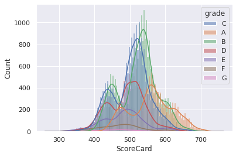

```python
sns.histplot(data = salida, x = "ScoreCard", kde = True, hue = "grade")
```

Se nota que la mayoría de persomas se encuentran entre los 450 y 550 Scorecard y la mayoría pertenecía a la categoría B y C

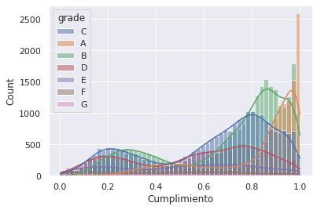

```python
sns.histplot(data = salida, x = "Cumplimiento", kde = True, hue = "grade")
```